# Association rules of market transactions

2023-01-23

## Introduction

### Association Rules is a very useful unsupervised learning method. The original motivation of association rules is to analyze the shopping basket, that is, the store wants to know whether there is any connection between the products purchased by customers.

## Data preparation

### The data is downloaded from the website https://www.kaggle.com/datasets/d4rklucif3r/market-basket-optimisation. This file contains some data of a supermarket customer purchasing goods.

```r
library(arules)
```

```r
library(arulesViz)
markert<-read.transactions("E:\\AAA Warsaw University\\The 1st semester\\Unsupervised Learning\\1Association\\Market_Basket_Optimisation.csv", format="basket", sep=",")
```

### General information about the data.

```r
summary(markert)
```

```
## transactions as itemMatrix in sparse format with
##  7501 rows (elements/itemsets/transactions) and
##  119 columns (items) and a density of 0.03288973
##
## most frequent items:
## mineral water          eggs     spaghetti  french fries     chocolate
##          1788          1348          1306          1282          1229
##       (Other)
##         22405
##
## element (itemset/transaction) length distribution:
## sizes
##    1    2    3    4    5    6    7    8    9   10   11   12   13   14   15   16
## 1754 1358 1044  816  667  493  391  324  259  139  102   67   40   22   17    4
##   18   19   20
##    1    2    1
##
##    Min. 1st Qu.  Median    Mean 3rd Qu.    Max.
##   1.000   2.000   3.000   3.914   5.000  20.000
##
## includes extended item information - examples:
##              labels
## 1           almonds
## 2 antioxydant juice
## 3         asparagus
```

```r
LIST(head(markert))
```

```
## [[1]]
##  [1] "almonds"           "antioxydant juice" "avocado"
##  [4] "cottage cheese"    "energy drink"      "frozen smoothie"
##  [7] "green grapes"      "green tea"         "honey"
## [10] "low fat yogurt"    "mineral water"     "olive oil"
## [13] "salad"             "salmon"            "shrimp"
## [16] "spinach"           "tomato juice"      "vegetables mix"
## [19] "whole weat flour"  "yams"
##
## [[2]]
## [1] "burgers"   "eggs"      "meatballs"
##
## [[3]]
## [1] "chutney"
##
## [[4]]
## [1] "avocado" "turkey"
##
## [[5]]
## [1] "energy bar"       "green tea"        "milk"             "mineral water"
## [5] "whole wheat rice"
##
## [[6]]
## [1] "low fat yogurt"
```

### How often each item appears

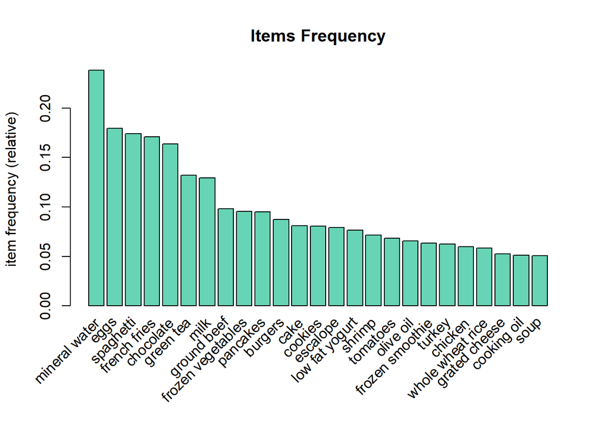

```r
itemFrequencyPlot(markert, topN=25, type="relative", main="Items Frequency",col='#66d4b5')
```

### The simple information obtained through the above charts has 7501 transactions and 119 items, among which mineral water appears most frequently. So are most of the commodities related to mineral water?

## Apriori algorithm

#### Support: support(A=>B) = P(A∪B), indicating the probability that A and B appear at the same time.

#### Confidence: confidence(A=>B)=support(A∪B) / support(A), indicating the ratio of the probability of A and B appearing at the same time to the probability of A appearing.

#### Lift: the degree to which the appearance of product A increases the probability of product B. Lift (A->B) = Confidence (A->B)/Support (B). When the lift is greater than 1 , it is recommended, if it is less than 1, it is not recommended.

#### First set Support to 0.05 and Confidence to 0.42.

```r
rules<-apriori(markert, parameter=list(supp=0.05, conf=0.42,minlen=2))
```

```
## Apriori
##
## Parameter specification:
##  confidence minval smax arem  aval originalSupport maxtime support minlen
##        0.42    0.1    1 none FALSE            TRUE       5    0.05      2
##  maxlen target  ext
##      10  rules TRUE
##
## Algorithmic control:
##  filter tree heap memopt load sort verbose
##     0.1 TRUE TRUE  FALSE TRUE    2    TRUE
##
## Absolute minimum support count: 375
##
## set item appearances ...[0 item(s)] done [0.00s].
## set transactions ...[119 item(s), 7501 transaction(s)] done [0.00s].
## sorting and recoding items ... [25 item(s)] done [0.00s].
## creating transaction tree ... done [0.00s].
## checking subsets of size 1 2 done [0.00s].
## writing ... [0 rule(s)] done [0.00s].
## creating S4 object  ... done [0.00s].
```

#### Because the conditions are relatively strict, we can see that there is no rule that meets such conditions.

#### We changed Support to 0.01 but Confidence to 0.42 as before.

```r
rules<-apriori(markert, parameter=list(supp=0.01, conf=0.42,minlen=2))
```

```
## Apriori
##
## Parameter specification:
##  confidence minval smax arem  aval originalSupport maxtime support minlen
##        0.42    0.1    1 none FALSE            TRUE       5    0.01      2
##  maxlen target  ext
##      10  rules TRUE
##
## Algorithmic control:
##  filter tree heap memopt load sort verbose
##     0.1 TRUE TRUE  FALSE TRUE    2    TRUE
##
## Absolute minimum support count: 75
##
## set item appearances ...[0 item(s)] done [0.00s].
## set transactions ...[119 item(s), 7501 transaction(s)] done [0.00s].
## sorting and recoding items ... [75 item(s)] done [0.00s].
## creating transaction tree ... done [0.00s].
## checking subsets of size 1 2 3 4 done [0.00s].
## writing ... [12 rule(s)] done [0.00s].
## creating S4 object  ... done [0.00s].
```

#### There are now 12 rules that meet Support to 0.01 and Confidence to 0.42.

## Visual Interaction Diagram

```r
rules_support = sort(rules,by = 'support')[1:12]
plot(rules_support,method = 'graph',engine = 'htmlwidget')
```

[interactive chart not shown]

```r
rules_confidence = sort(rules,by = 'confidence')[1:12]
plot(rules_confidence,method = 'graph',engine = 'htmlwidget')
```

[interactive chart not shown]

```r
rules_lift = sort(rules,by = 'lift')[1:12]
plot(rules_lift,method = 'graph',engine = 'htmlwidget')
```

[interactive chart not shown]

### From 3 above graphs we can see that each rule corresponds to the corresponding support, confidence and lift of the product.

### Sort by support, confidence, lift.

```r
rulesBYsupp<-sort(rules, by="support", decreasing=TRUE)
inspect(head(rulesBYsupp,12))
```

```
##      lhs                               rhs             support    confidence
## [1]  {soup}                         => {mineral water} 0.02306359 0.4564644
## [2]  {ground beef, spaghetti}       => {mineral water} 0.01706439 0.4353741
## [3]  {milk, spaghetti}              => {mineral water} 0.01573124 0.4436090
## [4]  {chocolate, milk}              => {mineral water} 0.01399813 0.4356846
## [5]  {eggs, milk}                   => {mineral water} 0.01306492 0.4242424
## [6]  {frozen vegetables, spaghetti} => {mineral water} 0.01199840 0.4306220
## [7]  {pancakes, spaghetti}          => {mineral water} 0.01146514 0.4550265
## [8]  {frozen vegetables, milk}      => {mineral water} 0.01106519 0.4689266
## [9]  {ground beef, milk}            => {mineral water} 0.01106519 0.5030303
## [10] {chocolate, ground beef}       => {mineral water} 0.01093188 0.4739884
## [11] {olive oil, spaghetti}         => {mineral water} 0.01026530 0.4476744
## [12] {eggs, ground beef}            => {mineral water} 0.01013198 0.5066667
##      coverage   lift     count
## [1]  0.05052660 1.914955 173
## [2]  0.03919477 1.826477 128
## [3]  0.03546194 1.861024 118
## [4]  0.03212905 1.827780 105
## [5]  0.03079589 1.779778  98
## [6]  0.02786295 1.806541  90
## [7]  0.02519664 1.908923  86
## [8]  0.02359685 1.967236  83
## [9]  0.02199707 2.110308  83
## [10] 0.02306359 1.988472  82
## [11] 0.02293028 1.878079  77
## [12] 0.01999733 2.125563  76
```

#### Soup, ground beef, spaghetti these products support mineral water the most.

```r
rulesBYconf<-sort(rules, by="confidence", decreasing=TRUE)
inspect(head(rulesBYconf,12))
```

```
##      lhs                               rhs             support    confidence
## [1]  {eggs, ground beef}            => {mineral water} 0.01013198 0.5066667
## [2]  {ground beef, milk}            => {mineral water} 0.01106519 0.5030303
## [3]  {chocolate, ground beef}       => {mineral water} 0.01093188 0.4739884
## [4]  {frozen vegetables, milk}      => {mineral water} 0.01106519 0.4689266
## [5]  {soup}                         => {mineral water} 0.02306359 0.4564644
## [6]  {pancakes, spaghetti}          => {mineral water} 0.01146514 0.4550265
## [7]  {olive oil, spaghetti}         => {mineral water} 0.01026530 0.4476744
## [8]  {milk, spaghetti}              => {mineral water} 0.01573124 0.4436090
## [9]  {chocolate, milk}              => {mineral water} 0.01399813 0.4356846
## [10] {ground beef, spaghetti}       => {mineral water} 0.01706439 0.4353741
## [11] {frozen vegetables, spaghetti} => {mineral water} 0.01199840 0.4306220
## [12] {eggs, milk}                   => {mineral water} 0.01306492 0.4242424
##      coverage   lift     count
## [1]  0.01999733 2.125563  76
## [2]  0.02199707 2.110308  83
## [3]  0.02306359 1.988472  82
## [4]  0.02359685 1.967236  83
## [5]  0.05052660 1.914955 173
## [6]  0.02519664 1.908923  86
## [7]  0.02293028 1.878079  77
## [8]  0.03546194 1.861024 118
## [9]  0.03212905 1.827780 105
## [10] 0.03919477 1.826477 128
## [11] 0.02786295 1.806541  90
## [12] 0.03079589 1.779778  98
```

#### Products such as eggs, ground beef, and milk have the highest confidence for mineral water.

```r
rulesBYlift<-sort(rules, by="lift", decreasing=TRUE)
inspect(head(rulesBYlift,12))
```

```
##      lhs                               rhs             support    confidence
## [1]  {eggs, ground beef}            => {mineral water} 0.01013198 0.5066667
## [2]  {ground beef, milk}            => {mineral water} 0.01106519 0.5030303
## [3]  {chocolate, ground beef}       => {mineral water} 0.01093188 0.4739884
## [4]  {frozen vegetables, milk}      => {mineral water} 0.01106519 0.4689266
## [5]  {soup}                         => {mineral water} 0.02306359 0.4564644
## [6]  {pancakes, spaghetti}          => {mineral water} 0.01146514 0.4550265
## [7]  {olive oil, spaghetti}         => {mineral water} 0.01026530 0.4476744
## [8]  {milk, spaghetti}              => {mineral water} 0.01573124 0.4436090
## [9]  {chocolate, milk}              => {mineral water} 0.01399813 0.4356846
## [10] {ground beef, spaghetti}       => {mineral water} 0.01706439 0.4353741
## [11] {frozen vegetables, spaghetti} => {mineral water} 0.01199840 0.4306220
## [12] {eggs, milk}                   => {mineral water} 0.01306492 0.4242424
##      coverage   lift     count
## [1]  0.01999733 2.125563  76
## [2]  0.02199707 2.110308  83
## [3]  0.02306359 1.988472  82
## [4]  0.02359685 1.967236  83
## [5]  0.05052660 1.914955 173
## [6]  0.02519664 1.908923  86
## [7]  0.02293028 1.878079  77
## [8]  0.03546194 1.861024 118
## [9]  0.03212905 1.827780 105
## [10] 0.03919477 1.826477 128
## [11] 0.02786295 1.806541  90
## [12] 0.03079589 1.779778  98
```

#### Products such as eggs, ground beef, and milk have the highest lift for mineral water.

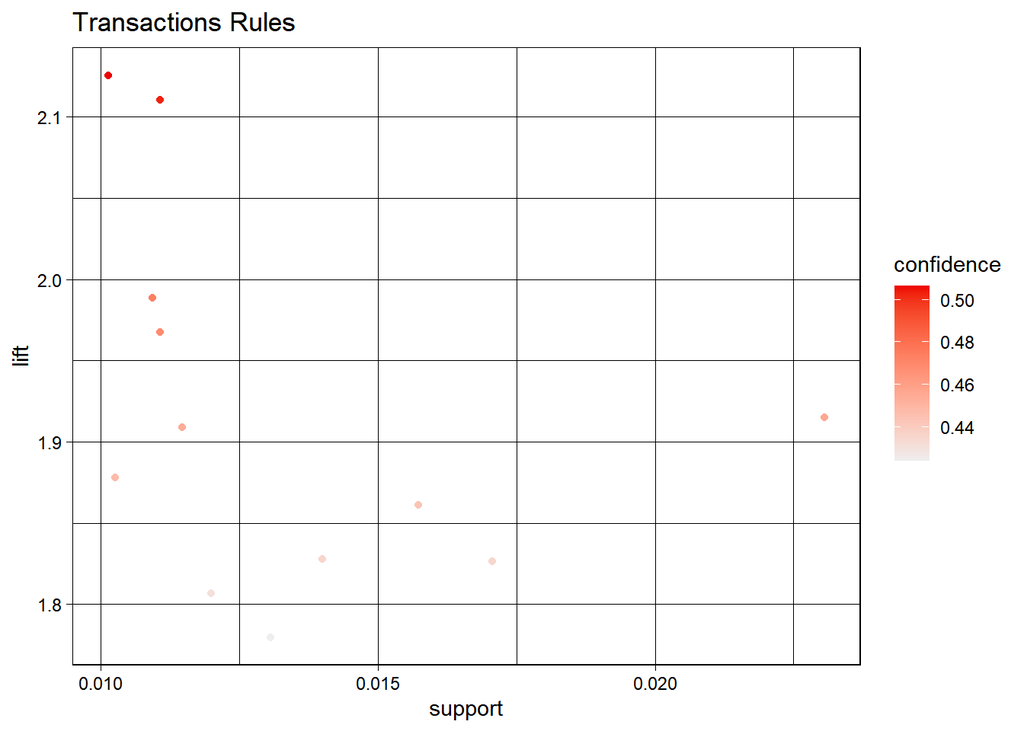

```r
plot_rules <- plot(rules, measure=c("support","lift"), shading="confidence", main="Transactions Rules")
plot_rules
```

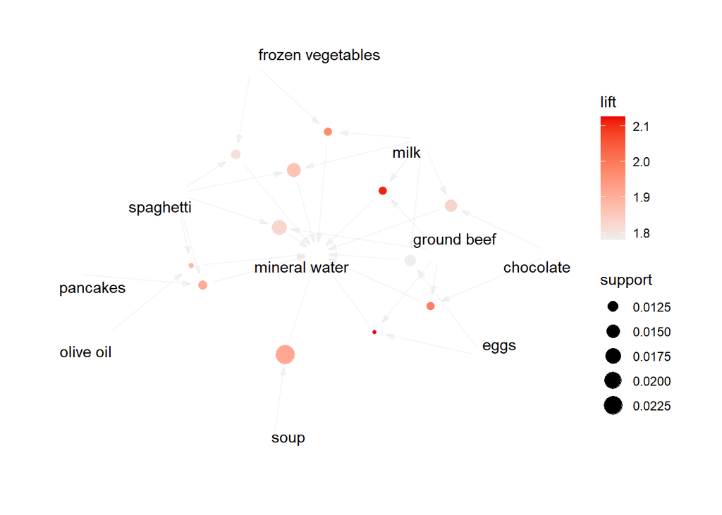

```r
plot(rules, method="graph", measure="support", shading="lift")
```

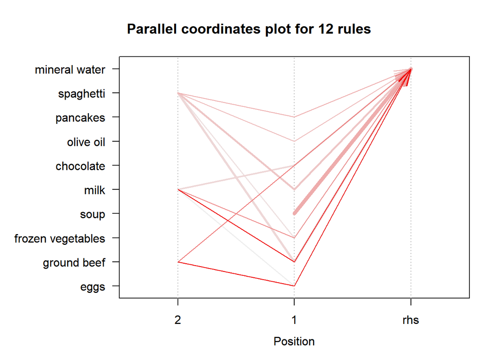

```r
plot(rules, method="paracoord", control=list(reorder=TRUE))
```

#### Spaghetti, milk, ground beef have a strong correlation with mineral water.

## Another example

#### We want to know what are the products related to the soup when the support is 0.01 and the confidence is 0.01.

```r
rules_soup<-apriori(data=markert, parameter=list(supp=0.01,conf = 0.01),
                      appearance=list(default="lhs", rhs="soup"))
```

```
## Apriori
##
## Parameter specification:
##  confidence minval smax arem  aval originalSupport maxtime support minlen
##        0.01    0.1    1 none FALSE            TRUE       5    0.01      1
##  maxlen target  ext
##      10  rules TRUE
##
## Algorithmic control:
##  filter tree heap memopt load sort verbose
##     0.1 TRUE TRUE  FALSE TRUE    2    TRUE
##
## Absolute minimum support count: 75
##
## set item appearances ...[1 item(s)] done [0.00s].
## set transactions ...[119 item(s), 7501 transaction(s)] done [0.00s].
## sorting and recoding items ... [75 item(s)] done [0.00s].
## creating transaction tree ... done [0.00s].
## checking subsets of size 1 2 3 4 done [0.00s].
## writing ... [5 rule(s)] done [0.00s].
## creating S4 object  ... done [0.00s].
```

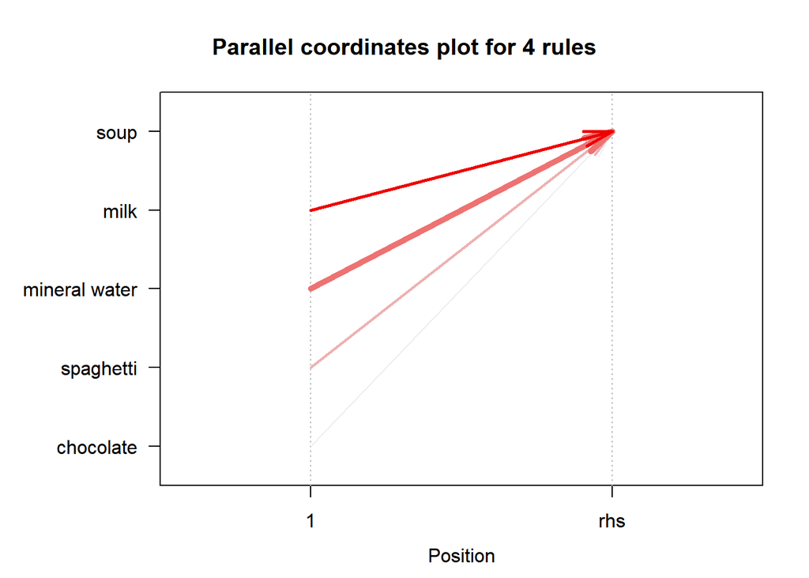

```r
plot(rules_soup, method="paracoord", control=list(reorder=TRUE))
```

#### We can see that milk, mineral water, pasta have a strong association with soup.

## Conclusion

### In order to assist customers improve their shopping lists, association rules might be used in the world of retail. In order to advise customers to combine purchasing and selling of things under specific conditions, it is feasible to identify which items are connected together by evaluating the user’s prior shopping data. Association rules also have a significant impact in other sectors. For instance, association rules can be used in the area of health to assist individuals in forming appropriate lifestyle choices. In summary, association rules are employed often in daily life and might aid in improved understanding, therefore they can become more significant in the future.